# cavega_OriginalHomeworkCode_05

C. Vega

10/31/2019

# This is code for Homework 05: Bootstrapping Standard Errors and CIs for Linear Models

## Five Challenges

1. I had trouble interpreting the results from the linear model. It is unclear to me what exaclty each of the results means so it took longer to really compare it to the second part of the homework.
2. It was difficult to find a good example of bootstrapping. I tried a bunch of different ways from the modules, but none seemed to help. I finally settled on using the boot function which seemed to work.
3. I found the shell of the function I created online and it seemed to do what I wanted. However, I could not find a way to access the 1000 bootstrapped coefficients.
4. Once I got the confidence intervals from bootstrapping I wasn’t sure if there was much else to do.
5. I feel like I have missed a step of the homework. If any, can you tell me what you may have done that I have not?

## Loading in the Dataset “Kamilar and Cooper”

```r
library(curl)
f <- curl("https://raw.githubusercontent.com/fuzzyatelin/fuzzyatelin.github.io/master/AN597_Fall19/KamilarAndCooperData.csv")
d <- read.csv(f, header = TRUE, sep = ",", stringsAsFactors = FALSE)
head(d)
```

```
##               Scientific_Name          Family          Genus      Species
## 1 Allenopithecus_nigroviridis Cercopithecidae Allenopithecus nigroviridis
## 2         Allocebus_trichotis Cercopithecidae      Allocebus    trichotis
## 3           Alouatta_belzebul        Atelidae       Alouatta     belzebul
## 4             Alouatta_caraya        Atelidae       Alouatta       caraya
## 5            Alouatta_guariba        Atelidae       Alouatta      guariba
## 6           Alouatta_palliata        Atelidae       Alouatta     palliata
##   Brain_Size_Species_Mean Brain_Size_Female_Mean   Brain_size_Ref
## 1                   58.02                  53.70 Isler et al 2008
## 2                      NA                     NA
## 3                   52.84                  51.19 Isler et al 2008
## 4                   52.63                  47.80 Isler et al 2008
## 5                   51.70                  49.08 Isler et al 2008
## 6                   49.88                  48.04 Isler et al 2008
##   Body_mass_male_mean Body_mass_female_mean Mass_Dimorphism
```

[output cut: 69 more lines]

## Create a Linear Regression for Log Home Range and Log Female Body Mass

## Linear equation: y=1.04x-9.44

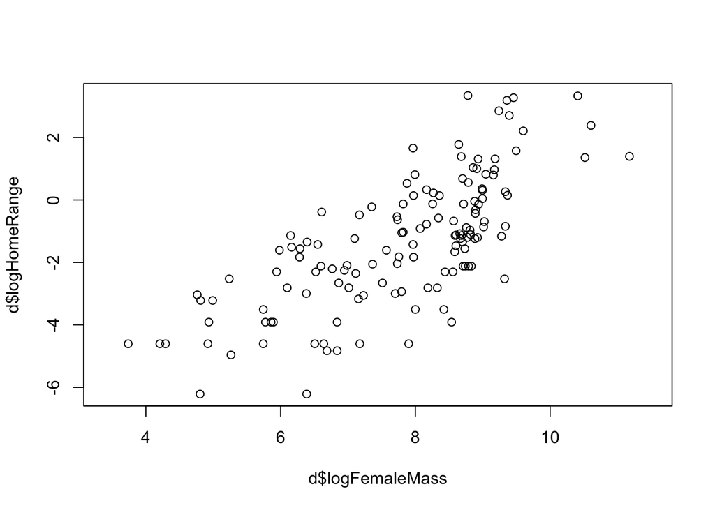

```r
library("ggplot2")
library(car)
d$logHomeRange <- log(d$HomeRange_km2)
d$logFemaleMass <- log(d$Body_mass_female_mean)

plot(data=d, d$logHomeRange~d$logFemaleMass) #quick plot to look at relationship
```

```r
LogModel <- lm(d$logHomeRange~d$logFemaleMass, data=d)
LogModel #model to use with the graph
```

```
##
## Call:
## lm(formula = d$logHomeRange ~ d$logFemaleMass, data = d)
##
## Coefficients:
##     (Intercept)  d$logFemaleMass
##          -9.441            1.036
```

```r
summary(LogModel)
```

```
##
## Call:
## lm(formula = d$logHomeRange ~ d$logFemaleMass, data = d)
##
## Residuals:
##     Min      1Q  Median      3Q     Max
## -3.3929 -0.9433 -0.0126  1.0944  3.6826
##
## Coefficients:
##                 Estimate Std. Error t value Pr(>|t|)
## (Intercept)     -9.44123    0.67293  -14.03   <2e-16 ***
## d$logFemaleMass  1.03643    0.08488   12.21   <2e-16 ***
## ---
## Signif. codes:  0 '***' 0.001 '**' 0.01 '*' 0.05 '.' 0.1 ' ' 1
##
## Residual standard error: 1.423 on 135 degrees of freedom
##   (76 observations deleted due to missingness)
## Multiple R-squared:  0.5248, Adjusted R-squared:  0.5213
## F-statistic: 149.1 on 1 and 135 DF,  p-value: < 2.2e-16
```

```r
names(LogModel)
```

```
##  [1] "coefficients"  "residuals"     "effects"       "rank"
##  [5] "fitted.values" "assign"        "qr"            "df.residual"
##  [9] "na.action"     "xlevels"       "call"          "terms"
## [13] "model"
```

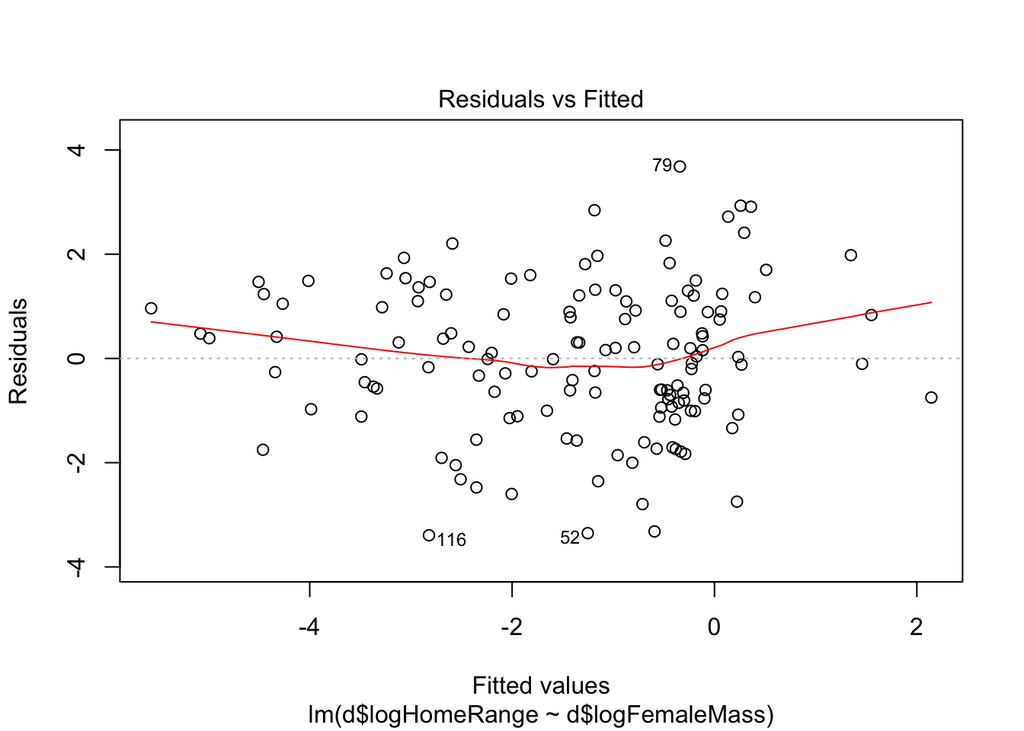

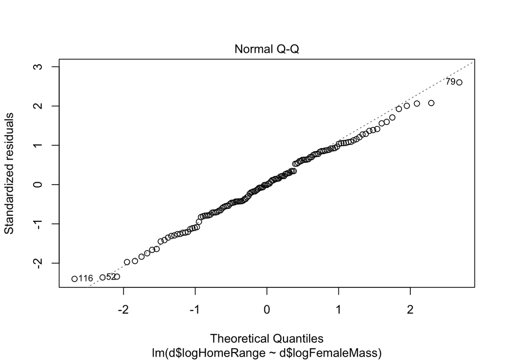

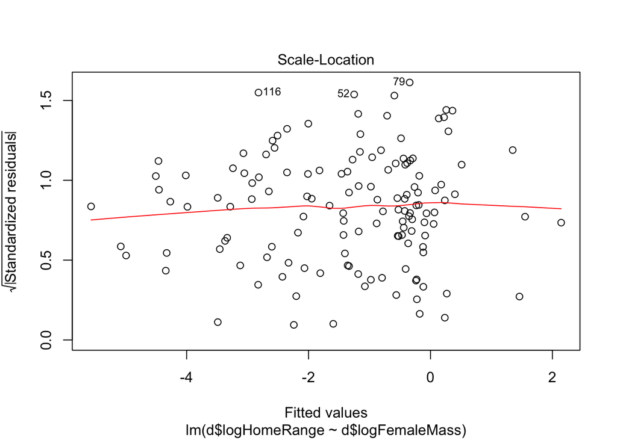

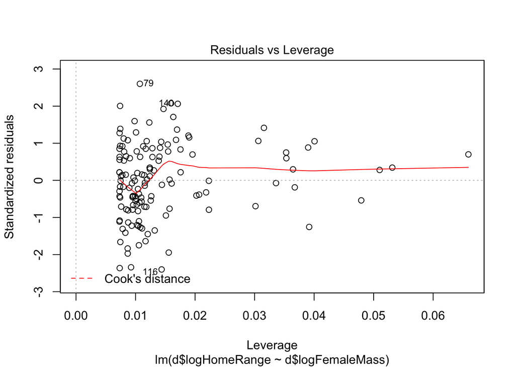

```r
plot(LogModel)
```

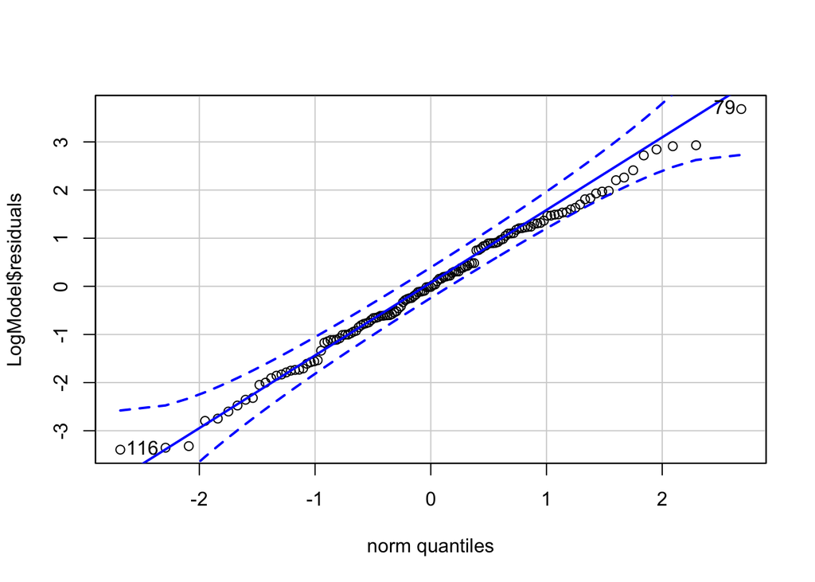

```
##  79 116
##  46  74
```

```r
# Plotting residuals
qqPlot(LogModel$residuals)
```

```r
# Perform Shapiro test to show normality
s <- shapiro.test(LogModel$residuals)
s
```

```
##
##  Shapiro-Wilk normality test
##
## data:  LogModel$residuals
## W = 0.99387, p-value = 0.8258
```

# Writing a function to perform bootstrap

```r
library(boot)
bs <- function(formula, data, indices) {
    d <- data[indices,]
    fit <- lm(d$logHomeRange~d$logFemaleMass, data=d)
    return(coef(fit))
}

results <- boot(data=d, statistic=bs, R=1000, formula=d$logHomeRange~d$logFemaleMass)

results
```

```
##
## ORDINARY NONPARAMETRIC BOOTSTRAP
##
##
## Call:
## boot(data = d, statistic = bs, R = 1000, formula = d$logHomeRange ~
##     d$logFemaleMass)
##
##
## Bootstrap Statistics :
##      original       bias    std. error
## t1* -9.441231 -0.034753794  0.61416218
## t2*  1.036432  0.004092406  0.07841339
```

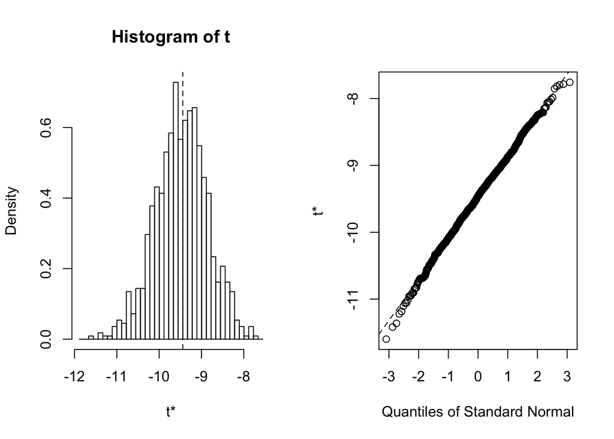

```r
plot(results, index=1) # intercept
```

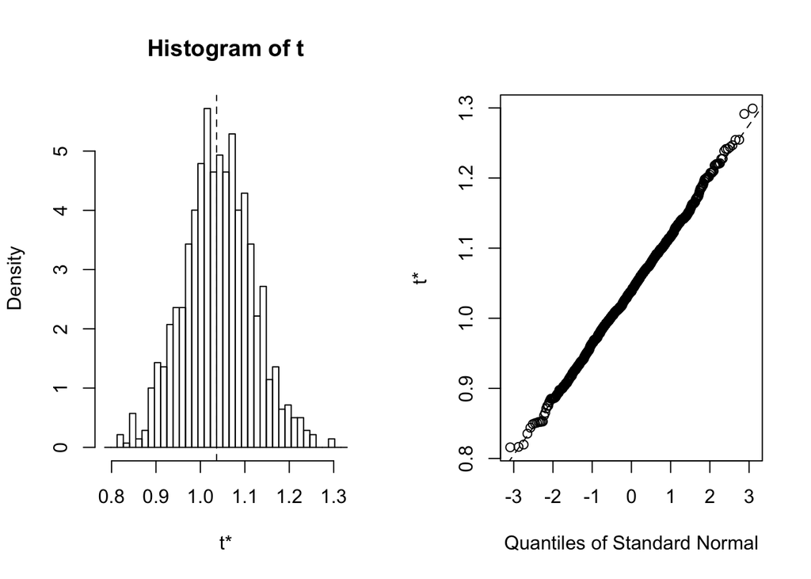

```r
plot(results, index=2) # wt
```

```r
# get 95% confidence intervals
boot.ci(results, type="bca", index=1) # intercept
```

```
## BOOTSTRAP CONFIDENCE INTERVAL CALCULATIONS
## Based on 1000 bootstrap replicates
##
## CALL :
## boot.ci(boot.out = results, type = "bca", index = 1)
##
## Intervals :
## Level       BCa
## 95%   (-10.688,  -8.250 )
## Calculations and Intervals on Original Scale
```

```r
boot.ci(results, type="bca", index=2) # wt
```

```
## BOOTSTRAP CONFIDENCE INTERVAL CALCULATIONS
## Based on 1000 bootstrap replicates
##
## CALL :
## boot.ci(boot.out = results, type = "bca", index = 2)
##
## Intervals :
## Level       BCa
## 95%   ( 0.885,  1.199 )
## Calculations and Intervals on Original Scale
```

# End of Homework Question:

> **Estimate the standard error for each of your β coefficients as the standard deviation of the sampling distribution from your bootstrap and determine the 95% CI for each of your β coefficients based on the appropriate quantiles from your sampling distribution.** I am unsure of how to do this, but I think I have calculated the data needed in order to get the answer.

> **How does the former compare to the SE estimated from your entire dataset using the formula for standard error implemented in lm()?** The standard error between the two only differ slightly.

> **How does the latter compare to the 95% CI estimated from your entire dataset?** I don’t think I calculate a confidence interval for my entire dataset. If I have, where in the results would I find them?